# Risk Factor Analysis

## Outcome Variable

**Outcome Variable:** y_rate_len

## Predictor Variables

**Intervention Variable:** exclfeed36

**Adjustment Set:**

unadjusted

## Stratifying Variables

The analysis was stratified on these variable(s):

- agecat
- studyid
- country

## Data Summary

| agecat | studyid | country | exclfeed36 | n_cell | n |
| --- | --- | --- | --- | --- | --- |
| 0-3 months | ki0047075b-MAL-ED | BANGLADESH | 0 | 180 | 242 |
| 0-3 months | ki0047075b-MAL-ED | BANGLADESH | 1 | 62 | 242 |
| 0-3 months | ki0047075b-MAL-ED | BRAZIL | 0 | 167 | 180 |
| 0-3 months | ki0047075b-MAL-ED | BRAZIL | 1 | 13 | 180 |
| 0-3 months | ki0047075b-MAL-ED | INDIA | 0 | 195 | 200 |
| 0-3 months | ki0047075b-MAL-ED | INDIA | 1 | 5 | 200 |
| 0-3 months | ki0047075b-MAL-ED | NEPAL | 0 | 163 | 175 |
| 0-3 months | ki0047075b-MAL-ED | NEPAL | 1 | 12 | 175 |
| 0-3 months | ki0047075b-MAL-ED | PERU | 0 | 254 | 269 |
| 0-3 months | ki0047075b-MAL-ED | PERU | 1 | 15 | 269 |
| 0-3 months | ki0047075b-MAL-ED | SOUTH AFRICA | 0 | 229 | 229 |
| 0-3 months | ki0047075b-MAL-ED | SOUTH AFRICA | 1 | 0 | 229 |
| 0-3 months | ki0047075b-MAL-ED | TANZANIA, UNITED REPUBLIC OF | 0 | 228 | 229 |
| 0-3 months | ki0047075b-MAL-ED | TANZANIA, UNITED REPUBLIC OF | 1 | 1 | 229 |
| 0-3 months | ki1000108-CMC-V-BCS-2002 | INDIA | 0 | 0 | 2 |
| 0-3 months | ki1000108-CMC-V-BCS-2002 | INDIA | 1 | 2 | 2 |
| 0-3 months | ki1000108-IRC | INDIA | 0 | 4 | 4 |
| 0-3 months | ki1000108-IRC | INDIA | 1 | 0 | 4 |
| 0-3 months | ki1000109-EE | PAKISTAN | 0 | 252 | 594 |
| 0-3 months | ki1000109-EE | PAKISTAN | 1 | 342 | 594 |
| 0-3 months | ki1017093b-PROVIDE | BANGLADESH | 0 | 459 | 628 |
| 0-3 months | ki1017093b-PROVIDE | BANGLADESH | 1 | 169 | 628 |
| 0-3 months | ki1101329-Keneba | GAMBIA | 0 | 790 | 1116 |
| 0-3 months | ki1101329-Keneba | GAMBIA | 1 | 326 | 1116 |
| 0-3 months | kiGH5241-JiVitA-3 | BANGLADESH | 0 | 6042 | 30184 |
| 0-3 months | kiGH5241-JiVitA-3 | BANGLADESH | 1 | 24142 | 30184 |
| 0-3 months | kiGH5241-JiVitA-4 | BANGLADESH | 0 | 572 | 3370 |
| 0-3 months | kiGH5241-JiVitA-4 | BANGLADESH | 1 | 2798 | 3370 |
| 3-6 months | ki0047075b-MAL-ED | BANGLADESH | 0 | 169 | 230 |
| 3-6 months | ki0047075b-MAL-ED | BANGLADESH | 1 | 61 | 230 |

[output cut: 92 more lines]

The following strata were considered:

- agecat: 0-3 months, studyid: ki0047075b-MAL-ED, country: BANGLADESH
- agecat: 0-3 months, studyid: ki0047075b-MAL-ED, country: BRAZIL
- agecat: 0-3 months, studyid: ki0047075b-MAL-ED, country: INDIA
- agecat: 0-3 months, studyid: ki0047075b-MAL-ED, country: NEPAL
- agecat: 0-3 months, studyid: ki0047075b-MAL-ED, country: PERU
- agecat: 0-3 months, studyid: ki0047075b-MAL-ED, country: SOUTH AFRICA
- agecat: 0-3 months, studyid: ki0047075b-MAL-ED, country: TANZANIA, UNITED REPUBLIC OF
- agecat: 0-3 months, studyid: ki1000108-CMC-V-BCS-2002, country: INDIA
- agecat: 0-3 months, studyid: ki1000108-IRC, country: INDIA
- agecat: 0-3 months, studyid: ki1000109-EE, country: PAKISTAN
- agecat: 0-3 months, studyid: ki1017093b-PROVIDE, country: BANGLADESH
- agecat: 0-3 months, studyid: ki1101329-Keneba, country: GAMBIA
- agecat: 0-3 months, studyid: kiGH5241-JiVitA-3, country: BANGLADESH
- agecat: 0-3 months, studyid: kiGH5241-JiVitA-4, country: BANGLADESH
- agecat: 12-24 months, studyid: ki0047075b-MAL-ED, country: BANGLADESH
- agecat: 12-24 months, studyid: ki0047075b-MAL-ED, country: BRAZIL
- agecat: 12-24 months, studyid: ki0047075b-MAL-ED, country: INDIA
- agecat: 12-24 months, studyid: ki0047075b-MAL-ED, country: NEPAL
- agecat: 12-24 months, studyid: ki0047075b-MAL-ED, country: PERU
- agecat: 12-24 months, studyid: ki0047075b-MAL-ED, country: SOUTH AFRICA
- agecat: 12-24 months, studyid: ki0047075b-MAL-ED, country: TANZANIA, UNITED REPUBLIC OF
- agecat: 12-24 months, studyid: ki1000108-CMC-V-BCS-2002, country: INDIA
- agecat: 12-24 months, studyid: ki1000108-IRC, country: INDIA
- agecat: 12-24 months, studyid: ki1017093b-PROVIDE, country: BANGLADESH
- agecat: 12-24 months, studyid: ki1101329-Keneba, country: GAMBIA
- agecat: 12-24 months, studyid: ki1113344-GMS-Nepal, country: NEPAL
- agecat: 12-24 months, studyid: ki1148112-LCNI-5, country: MALAWI
- agecat: 12-24 months, studyid: kiGH5241-JiVitA-3, country: BANGLADESH
- agecat: 12-24 months, studyid: kiGH5241-JiVitA-4, country: BANGLADESH
- agecat: 3-6 months, studyid: ki0047075b-MAL-ED, country: BANGLADESH
- agecat: 3-6 months, studyid: ki0047075b-MAL-ED, country: BRAZIL
- agecat: 3-6 months, studyid: ki0047075b-MAL-ED, country: INDIA
- agecat: 3-6 months, studyid: ki0047075b-MAL-ED, country: NEPAL
- agecat: 3-6 months, studyid: ki0047075b-MAL-ED, country: PERU
- agecat: 3-6 months, studyid: ki0047075b-MAL-ED, country: SOUTH AFRICA
- agecat: 3-6 months, studyid: ki0047075b-MAL-ED, country: TANZANIA, UNITED REPUBLIC OF
- agecat: 3-6 months, studyid: ki1000108-CMC-V-BCS-2002, country: INDIA
- agecat: 3-6 months, studyid: ki1000108-IRC, country: INDIA
- agecat: 3-6 months, studyid: ki1000109-EE, country: PAKISTAN
- agecat: 3-6 months, studyid: ki1017093b-PROVIDE, country: BANGLADESH
- agecat: 3-6 months, studyid: ki1101329-Keneba, country: GAMBIA
- agecat: 3-6 months, studyid: ki1113344-GMS-Nepal, country: NEPAL
- agecat: 3-6 months, studyid: kiGH5241-JiVitA-3, country: BANGLADESH
- agecat: 3-6 months, studyid: kiGH5241-JiVitA-4, country: BANGLADESH
- agecat: 6-12 months, studyid: ki0047075b-MAL-ED, country: BANGLADESH
- agecat: 6-12 months, studyid: ki0047075b-MAL-ED, country: BRAZIL
- agecat: 6-12 months, studyid: ki0047075b-MAL-ED, country: INDIA
- agecat: 6-12 months, studyid: ki0047075b-MAL-ED, country: NEPAL
- agecat: 6-12 months, studyid: ki0047075b-MAL-ED, country: PERU
- agecat: 6-12 months, studyid: ki0047075b-MAL-ED, country: SOUTH AFRICA
- agecat: 6-12 months, studyid: ki0047075b-MAL-ED, country: TANZANIA, UNITED REPUBLIC OF
- agecat: 6-12 months, studyid: ki1000108-CMC-V-BCS-2002, country: INDIA
- agecat: 6-12 months, studyid: ki1000108-IRC, country: INDIA
- agecat: 6-12 months, studyid: ki1000109-EE, country: PAKISTAN
- agecat: 6-12 months, studyid: ki1000304b-SAS-FoodSuppl, country: INDIA
- agecat: 6-12 months, studyid: ki1017093b-PROVIDE, country: BANGLADESH
- agecat: 6-12 months, studyid: ki1101329-Keneba, country: GAMBIA
- agecat: 6-12 months, studyid: ki1113344-GMS-Nepal, country: NEPAL
- agecat: 6-12 months, studyid: ki1148112-LCNI-5, country: MALAWI
- agecat: 6-12 months, studyid: kiGH5241-JiVitA-3, country: BANGLADESH
- agecat: 6-12 months, studyid: kiGH5241-JiVitA-4, country: BANGLADESH

### Dropped Strata

- agecat: 0-3 months, studyid: ki0047075b-MAL-ED, country: SOUTH AFRICA
- agecat: 0-3 months, studyid: ki0047075b-MAL-ED, country: TANZANIA, UNITED REPUBLIC OF
- agecat: 0-3 months, studyid: ki1000108-CMC-V-BCS-2002, country: INDIA
- agecat: 0-3 months, studyid: ki1000108-IRC, country: INDIA
- agecat: 3-6 months, studyid: ki0047075b-MAL-ED, country: SOUTH AFRICA
- agecat: 3-6 months, studyid: ki0047075b-MAL-ED, country: TANZANIA, UNITED REPUBLIC OF
- agecat: 3-6 months, studyid: ki1000108-CMC-V-BCS-2002, country: INDIA
- agecat: 3-6 months, studyid: ki1000108-IRC, country: INDIA
- agecat: 6-12 months, studyid: ki0047075b-MAL-ED, country: SOUTH AFRICA
- agecat: 6-12 months, studyid: ki0047075b-MAL-ED, country: TANZANIA, UNITED REPUBLIC OF
- agecat: 6-12 months, studyid: ki1000108-CMC-V-BCS-2002, country: INDIA
- agecat: 6-12 months, studyid: ki1000108-IRC, country: INDIA
- agecat: 6-12 months, studyid: ki1000109-EE, country: PAKISTAN
- agecat: 6-12 months, studyid: ki1000304b-SAS-FoodSuppl, country: INDIA
- agecat: 12-24 months, studyid: ki0047075b-MAL-ED, country: SOUTH AFRICA
- agecat: 12-24 months, studyid: ki0047075b-MAL-ED, country: TANZANIA, UNITED REPUBLIC OF
- agecat: 12-24 months, studyid: ki1000108-CMC-V-BCS-2002, country: INDIA
- agecat: 12-24 months, studyid: ki1000108-IRC, country: INDIA

## Methods Detail

We’re interested in the causal parameters $E[Y_a]$ for all values of $a \in \mathcal{A}$. These parameters represent the mean outcome if, possibly contrary to fact, we intervened to set all units to have $A=a$. Under the randomization and positivity assumptions, these are identified by the statistical parameters $\psi_a=E_W[E_{Y|A,W}(Y|A=a,W)]$. In addition, we’re interested in the mean of $Y$, $E[Y]$ under no intervention (the observed mean). We will estimate these parameters by using SuperLearner to fit the relevant likelihood factors – $E_{Y|A,W}(Y|A=a,W)$ and $p(A=a|W)$, and then updating our likelihood fit using a joint TMLE.

For unadjusted analyses ($W=\{\}$), initial likelihoods were estimated using Lrnr_glm to estimate the simple $E(Y|A)$ and Lrnr_mean to estimate $p(A)$. For adjusted analyses, a small library containing Lrnr_glmnet, Lrnr_xgboost, and Lrnr_mean was used.

Having estimated these parameters, we will then use the delta method to estimate relative risks and attributable risks relative to a prespecified baseline level of $A$.

# Results Detail

## Results Plots

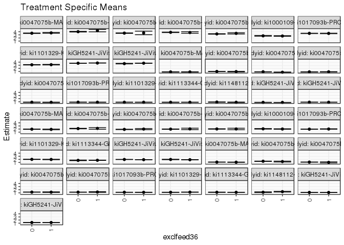

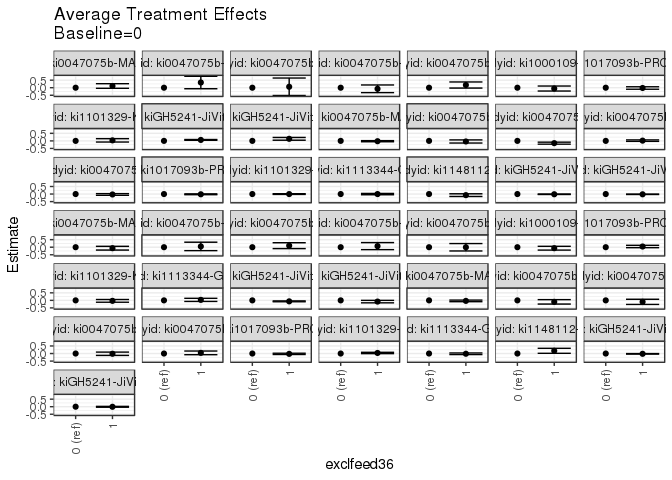

## Results Table

### Parameter: TSM

| agecat | studyid | country | intervention_level | baseline_level | estimate | ci_lower | ci_upper |
| --- | --- | --- | --- | --- | --- | --- | --- |
| 0-3 months | ki0047075b-MAL-ED | BANGLADESH | 0 | NA | 3.5334160 | 3.4626941 | 3.6041379 |
| 0-3 months | ki0047075b-MAL-ED | BANGLADESH | 1 | NA | 3.6462435 | 3.5109341 | 3.7815530 |
| 0-3 months | ki0047075b-MAL-ED | BRAZIL | 0 | NA | 4.0260084 | 3.9218035 | 4.1302132 |
| 0-3 months | ki0047075b-MAL-ED | BRAZIL | 1 | NA | 4.3716500 | 3.9727968 | 4.7705033 |
| 0-3 months | ki0047075b-MAL-ED | INDIA | 0 | NA | 3.5639428 | 3.4872597 | 3.6406259 |
| 0-3 months | ki0047075b-MAL-ED | INDIA | 1 | NA | 3.6269354 | 3.0524083 | 4.2014624 |
| 0-3 months | ki0047075b-MAL-ED | NEPAL | 0 | NA | 3.8254902 | 3.7458259 | 3.9051545 |
| 0-3 months | ki0047075b-MAL-ED | NEPAL | 1 | NA | 3.7526220 | 3.5112351 | 3.9940088 |
| 0-3 months | ki0047075b-MAL-ED | PERU | 0 | NA | 3.3055165 | 3.2392345 | 3.3717985 |
| 0-3 months | ki0047075b-MAL-ED | PERU | 1 | NA | 3.4842935 | 3.2937954 | 3.6747917 |
| 0-3 months | ki1000109-EE | PAKISTAN | 0 | NA | 2.6883206 | 2.5700483 | 2.8065928 |
| 0-3 months | ki1000109-EE | PAKISTAN | 1 | NA | 2.6349021 | 2.5189519 | 2.7508523 |
| 0-3 months | ki1017093b-PROVIDE | BANGLADESH | 0 | NA | 3.4862606 | 3.4388551 | 3.5336660 |
| 0-3 months | ki1017093b-PROVIDE | BANGLADESH | 1 | NA | 3.4685323 | 3.4015917 | 3.5354728 |
| 0-3 months | ki1101329-Keneba | GAMBIA | 0 | NA | 3.1362817 | 3.0743892 | 3.1981742 |
| 0-3 months | ki1101329-Keneba | GAMBIA | 1 | NA | 3.1710550 | 3.0785010 | 3.2636089 |
| 0-3 months | kiGH5241-JiVitA-3 | BANGLADESH | 0 | NA | 3.6430070 | 3.6191064 | 3.6669075 |
| 0-3 months | kiGH5241-JiVitA-3 | BANGLADESH | 1 | NA | 3.7061644 | 3.6937006 | 3.7186282 |
| 0-3 months | kiGH5241-JiVitA-4 | BANGLADESH | 0 | NA | 3.5142065 | 3.4300108 | 3.5984021 |
| 0-3 months | kiGH5241-JiVitA-4 | BANGLADESH | 1 | NA | 3.6503139 | 3.6168063 | 3.6838216 |
| 3-6 months | ki0047075b-MAL-ED | BANGLADESH | 0 | NA | 1.9476481 | 1.8940331 | 2.0012630 |
| 3-6 months | ki0047075b-MAL-ED | BANGLADESH | 1 | NA | 1.8819928 | 1.7710058 | 1.9929797 |
| 3-6 months | ki0047075b-MAL-ED | BRAZIL | 0 | NA | 2.1435888 | 2.0607273 | 2.2264503 |
| 3-6 months | ki0047075b-MAL-ED | BRAZIL | 1 | NA | 2.1953050 | 1.9283158 | 2.4622942 |
| 3-6 months | ki0047075b-MAL-ED | INDIA | 0 | NA | 1.8806029 | 1.8176929 | 1.9435129 |
| 3-6 months | ki0047075b-MAL-ED | INDIA | 1 | NA | 1.9827867 | 1.7992148 | 2.1663585 |
| 3-6 months | ki0047075b-MAL-ED | NEPAL | 0 | NA | 1.9637503 | 1.9059258 | 2.0215747 |
| 3-6 months | ki0047075b-MAL-ED | NEPAL | 1 | NA | 2.0361336 | 1.8101069 | 2.2621603 |
| 3-6 months | ki0047075b-MAL-ED | PERU | 0 | NA | 2.0198916 | 1.9513738 | 2.0884094 |
| 3-6 months | ki0047075b-MAL-ED | PERU | 1 | NA | 2.0148722 | 1.7797204 | 2.2500241 |

[output cut: 56 more lines]

### Parameter: E(Y)

| agecat | studyid | country | intervention_level | baseline_level | estimate | ci_lower | ci_upper |
| --- | --- | --- | --- | --- | --- | --- | --- |
| 0-3 months | ki0047075b-MAL-ED | BANGLADESH | NA | NA | 3.5623222 | 3.4990175 | 3.6256270 |
| 0-3 months | ki0047075b-MAL-ED | BRAZIL | NA | NA | 4.0509714 | 3.9492443 | 4.1526985 |
| 0-3 months | ki0047075b-MAL-ED | INDIA | NA | NA | 3.5655176 | 3.4893722 | 3.6416631 |
| 0-3 months | ki0047075b-MAL-ED | NEPAL | NA | NA | 3.8204935 | 3.7444190 | 3.8965681 |
| 0-3 months | ki0047075b-MAL-ED | PERU | NA | NA | 3.3154855 | 3.2518148 | 3.3791562 |
| 0-3 months | ki1000109-EE | PAKISTAN | NA | NA | 2.6575645 | 2.5739973 | 2.7411317 |
| 0-3 months | ki1017093b-PROVIDE | BANGLADESH | NA | NA | 3.4814897 | 3.4424334 | 3.5205460 |
| 0-3 months | ki1101329-Keneba | GAMBIA | NA | NA | 3.1464395 | 3.0949478 | 3.1979311 |
| 0-3 months | kiGH5241-JiVitA-3 | BANGLADESH | NA | NA | 3.6935220 | 3.6819690 | 3.7050750 |
| 0-3 months | kiGH5241-JiVitA-4 | BANGLADESH | NA | NA | 3.6272120 | 3.5957777 | 3.6586463 |
| 3-6 months | ki0047075b-MAL-ED | BANGLADESH | NA | NA | 1.9302352 | 1.8809143 | 1.9795560 |
| 3-6 months | ki0047075b-MAL-ED | BRAZIL | NA | NA | 2.1478156 | 2.0686357 | 2.2269955 |
| 3-6 months | ki0047075b-MAL-ED | INDIA | NA | NA | 1.8837264 | 1.8224393 | 1.9450135 |
| 3-6 months | ki0047075b-MAL-ED | NEPAL | NA | NA | 1.9680995 | 1.9120346 | 2.0241643 |
| 3-6 months | ki0047075b-MAL-ED | PERU | NA | NA | 2.0195897 | 1.9536580 | 2.0855214 |
| 3-6 months | ki1000109-EE | PAKISTAN | NA | NA | 2.0241201 | 1.9636505 | 2.0845898 |
| 3-6 months | ki1017093b-PROVIDE | BANGLADESH | NA | NA | 1.9678138 | 1.9329962 | 2.0026315 |
| 3-6 months | ki1101329-Keneba | GAMBIA | NA | NA | 1.9917249 | 1.9499823 | 2.0334676 |
| 3-6 months | ki1113344-GMS-Nepal | NEPAL | NA | NA | 1.7041512 | 1.6643719 | 1.7439304 |
| 3-6 months | kiGH5241-JiVitA-3 | BANGLADESH | NA | NA | 1.9109679 | 1.8993348 | 1.9226010 |
| 3-6 months | kiGH5241-JiVitA-4 | BANGLADESH | NA | NA | 1.8963017 | 1.8659335 | 1.9266699 |
| 6-12 months | ki0047075b-MAL-ED | BANGLADESH | NA | NA | 1.1143347 | 1.0894390 | 1.1392304 |
| 6-12 months | ki0047075b-MAL-ED | BRAZIL | NA | NA | 1.3863464 | 1.3400121 | 1.4326807 |
| 6-12 months | ki0047075b-MAL-ED | INDIA | NA | NA | 1.1210558 | 1.0926349 | 1.1494766 |
| 6-12 months | ki0047075b-MAL-ED | NEPAL | NA | NA | 1.2224454 | 1.1966480 | 1.2482429 |
| 6-12 months | ki0047075b-MAL-ED | PERU | NA | NA | 1.2102315 | 1.1775158 | 1.2429472 |
| 6-12 months | ki1017093b-PROVIDE | BANGLADESH | NA | NA | 1.1731762 | 1.1558671 | 1.1904853 |
| 6-12 months | ki1101329-Keneba | GAMBIA | NA | NA | 1.1798699 | 1.1605949 | 1.1991450 |
| 6-12 months | ki1113344-GMS-Nepal | NEPAL | NA | NA | 1.1652836 | 1.1455437 | 1.1850235 |
| 6-12 months | ki1148112-LCNI-5 | MALAWI | NA | NA | 1.2437855 | 1.1489803 | 1.3385906 |
| 6-12 months | kiGH5241-JiVitA-3 | BANGLADESH | NA | NA | 1.1137217 | 1.1063529 | 1.1210904 |
| 6-12 months | kiGH5241-JiVitA-4 | BANGLADESH | NA | NA | 1.2021162 | 1.1906438 | 1.2135885 |
| 12-24 months | ki0047075b-MAL-ED | BANGLADESH | NA | NA | 0.8466791 | 0.8306555 | 0.8627027 |
| 12-24 months | ki0047075b-MAL-ED | BRAZIL | NA | NA | 0.9816245 | 0.9508764 | 1.0123725 |
| 12-24 months | ki0047075b-MAL-ED | INDIA | NA | NA | 0.8803730 | 0.8630530 | 0.8976931 |
| 12-24 months | ki0047075b-MAL-ED | NEPAL | NA | NA | 0.8617083 | 0.8463512 | 0.8770654 |
| 12-24 months | ki0047075b-MAL-ED | PERU | NA | NA | 0.8463453 | 0.8256453 | 0.8670453 |
| 12-24 months | ki1017093b-PROVIDE | BANGLADESH | NA | NA | 0.8577912 | 0.8457808 | 0.8698015 |
| 12-24 months | ki1101329-Keneba | GAMBIA | NA | NA | 0.8453172 | 0.8340582 | 0.8565762 |
| 12-24 months | ki1113344-GMS-Nepal | NEPAL | NA | NA | 0.8352708 | 0.8193000 | 0.8512417 |
| 12-24 months | ki1148112-LCNI-5 | MALAWI | NA | NA | 0.8835736 | 0.8376943 | 0.9294529 |
| 12-24 months | kiGH5241-JiVitA-3 | BANGLADESH | NA | NA | 0.7961751 | 0.7903156 | 0.8020346 |
| 12-24 months | kiGH5241-JiVitA-4 | BANGLADESH | NA | NA | 0.8490566 | 0.8431830 | 0.8549302 |

### Parameter: ATE

| agecat | studyid | country | intervention_level | baseline_level | estimate | ci_lower | ci_upper |
| --- | --- | --- | --- | --- | --- | --- | --- |
| 0-3 months | ki0047075b-MAL-ED | BANGLADESH | 0 | 0 | 0.0000000 | 0.0000000 | 0.0000000 |
| 0-3 months | ki0047075b-MAL-ED | BANGLADESH | 1 | 0 | 0.1128275 | -0.0398494 | 0.2655045 |
| 0-3 months | ki0047075b-MAL-ED | BRAZIL | 0 | 0 | 0.0000000 | 0.0000000 | 0.0000000 |
| 0-3 months | ki0047075b-MAL-ED | BRAZIL | 1 | 0 | 0.3456417 | -0.0665992 | 0.7578825 |
| 0-3 months | ki0047075b-MAL-ED | INDIA | 0 | 0 | 0.0000000 | 0.0000000 | 0.0000000 |
| 0-3 months | ki0047075b-MAL-ED | INDIA | 1 | 0 | 0.0629925 | -0.5166294 | 0.6426145 |
| 0-3 months | ki0047075b-MAL-ED | NEPAL | 0 | 0 | 0.0000000 | 0.0000000 | 0.0000000 |
| 0-3 months | ki0047075b-MAL-ED | NEPAL | 1 | 0 | -0.0728682 | -0.3270611 | 0.1813246 |
| 0-3 months | ki0047075b-MAL-ED | PERU | 0 | 0 | 0.0000000 | 0.0000000 | 0.0000000 |
| 0-3 months | ki0047075b-MAL-ED | PERU | 1 | 0 | 0.1787770 | -0.0229229 | 0.3804769 |
| 0-3 months | ki1000109-EE | PAKISTAN | 0 | 0 | 0.0000000 | 0.0000000 | 0.0000000 |
| 0-3 months | ki1000109-EE | PAKISTAN | 1 | 0 | -0.0534185 | -0.2190469 | 0.1122099 |
| 0-3 months | ki1017093b-PROVIDE | BANGLADESH | 0 | 0 | 0.0000000 | 0.0000000 | 0.0000000 |
| 0-3 months | ki1017093b-PROVIDE | BANGLADESH | 1 | 0 | -0.0177283 | -0.0997546 | 0.0642980 |
| 0-3 months | ki1101329-Keneba | GAMBIA | 0 | 0 | 0.0000000 | 0.0000000 | 0.0000000 |
| 0-3 months | ki1101329-Keneba | GAMBIA | 1 | 0 | 0.0347733 | -0.0765681 | 0.1461147 |
| 0-3 months | kiGH5241-JiVitA-3 | BANGLADESH | 0 | 0 | 0.0000000 | 0.0000000 | 0.0000000 |
| 0-3 months | kiGH5241-JiVitA-3 | BANGLADESH | 1 | 0 | 0.0631575 | 0.0374937 | 0.0888213 |
| 0-3 months | kiGH5241-JiVitA-4 | BANGLADESH | 0 | 0 | 0.0000000 | 0.0000000 | 0.0000000 |
| 0-3 months | kiGH5241-JiVitA-4 | BANGLADESH | 1 | 0 | 0.1361075 | 0.0455347 | 0.2266802 |
| 3-6 months | ki0047075b-MAL-ED | BANGLADESH | 0 | 0 | 0.0000000 | 0.0000000 | 0.0000000 |
| 3-6 months | ki0047075b-MAL-ED | BANGLADESH | 1 | 0 | -0.0656553 | -0.1889139 | 0.0576032 |
| 3-6 months | ki0047075b-MAL-ED | BRAZIL | 0 | 0 | 0.0000000 | 0.0000000 | 0.0000000 |
| 3-6 months | ki0047075b-MAL-ED | BRAZIL | 1 | 0 | 0.0517162 | -0.2278356 | 0.3312681 |
| 3-6 months | ki0047075b-MAL-ED | INDIA | 0 | 0 | 0.0000000 | 0.0000000 | 0.0000000 |
| 3-6 months | ki0047075b-MAL-ED | INDIA | 1 | 0 | 0.1021838 | -0.0918686 | 0.2962361 |
| 3-6 months | ki0047075b-MAL-ED | NEPAL | 0 | 0 | 0.0000000 | 0.0000000 | 0.0000000 |
| 3-6 months | ki0047075b-MAL-ED | NEPAL | 1 | 0 | 0.0723833 | -0.1609227 | 0.3056894 |
| 3-6 months | ki0047075b-MAL-ED | PERU | 0 | 0 | 0.0000000 | 0.0000000 | 0.0000000 |
| 3-6 months | ki0047075b-MAL-ED | PERU | 1 | 0 | -0.0050194 | -0.2499502 | 0.2399114 |

[output cut: 56 more lines]